# Chapter4 Statistics-Variable Associations: Ravi Mummigatti : 24-12-20

# Introduction

Investigating relationships between variables is key to any data analysis or model-building endeavor. While the methods discussed in this chapter cannot tell us about causal relationships, they can help us understand how two things are related so that we can form testable hypotheses about why.

At the end of this module, you will be able to:

1. Use the following numerical summaries to quantify an association between two variables:
- Mean and Median Differences
- Covariance and Correlation
- Chi-Square Statistic
1. Use the following visualizations to look at relationships between variables:
- Side by Side Box Plots
- Overlapping Histograms
- Scatter Plots

# Association between Quantitative and Categorical Variables

In this lesson we will explore the relationship between quantitative and categorical variables.  
We’ll use different statistical methods such as mean median differences, side-by-side box plots, and overlapping histograms to try to assess whether or not an association exists between the variables  
We will explore a dataset that contains the following information about students at two portuguese schools:  
school: the school each student attends, Gabriel Periera ('GP') or Mousinho da Silveria ('MS')  
address: the location of the student’s home ('U' for urban and 'R' for rural)  
absences: the number of times the student was absent during the school year  
Mjob: the student’s mother’s job industry  
Fjob: the student’s father’s job industry  
G3: the student’s score on a math assessment, ranging from 0 to 20

## Quantitative and Binary Categorical Variable

Suppose we want to know: Is a student’s score (G3) associated with their school (school)?  
If so, then knowing what school a student attends gives us information about what their score is likely to be.

To start answering this question, it is useful to save scores from each school in two separate lists

```python
import pandas as pd
import numpy as np
```

**Data review**

```python
students = pd.read_csv('students_grades.csv')
students.head()
```

|  | school | address | absences | Mjob | Fjob | G3 |
| --- | --- | --- | --- | --- | --- | --- |
| 0 | GP | U | 6 | at_home | teacher | 6 |
| 1 | GP | U | 4 | at_home | other | 6 |
| 2 | GP | U | 10 | at_home | other | 10 |
| 3 | GP | U | 2 | health | services | 15 |
| 4 | GP | U | 4 | other | other | 10 |

```python
students.info()
```

```
<class 'pandas.core.frame.DataFrame'>
RangeIndex: 395 entries, 0 to 394
Data columns (total 6 columns):
 #   Column    Non-Null Count  Dtype
---  ------    --------------  -----
 0   school    395 non-null    object
 1   address   395 non-null    object
 2   absences  395 non-null    int64
 3   Mjob      395 non-null    object
 4   Fjob      395 non-null    object
 5   G3        395 non-null    int64
dtypes: int64(2), object(4)
memory usage: 18.6+ KB
```

Categorical Variables : school , address , Mjob , Fjob  
Numerical Variables : absences , G3

Suppose that we want to know whether there is an association between student math scores (G3) and the student’s address (urban or rural).  
Separate out G3 scores into two separate lists: one for students who live in an urban location ('U') and one for students who live in a rural location ('R').  
Name these lists scores_urban and scores_rural

```python
# list of urban & riral student scores
scores_urban = students.G3[students.address == 'U']
scores_rural = students.G3[students.address == 'R']
```

```python
# review
print(scores_urban.head())
print(scores_rural.head())
```

```
0     6
1     6
2    10
3    15
4    10
Name: G3, dtype: int64
24     8
32    16
37    15
38    11
39    13
Name: G3, dtype: int64
```

```python
# mean G3 scores for each group
scores_urban_mean = np.mean(scores_urban)
scores_rural_mean = np.mean(scores_rural)

#print mean scores:
print('Mean score - students w/ urban address: ' + str(scores_urban_mean))
print('Mean score - students w/ rural address: ' + str(scores_rural_mean))

# Calculate the mean difference between the two groups
mean_diff = scores_urban_mean - scores_rural_mean

#print mean difference
print('Mean difference: ' + str(mean_diff))

#calculate medians for each group:
scores_urban_median = np.median(scores_urban)
scores_rural_median = np.median(scores_rural)

#print median scores:
print('Median score - students w/ urban address: ' + str(scores_urban_median))
print('Median score - students w/ rural address: ' + str(scores_rural_median))

# Calculate the median difference between the two groups
median_diff = scores_urban_median - scores_rural_median

#print mean difference
print('Median difference: ' + str(median_diff))
```

```
Mean score - students w/ urban address: 10.674267100977199
Mean score - students w/ rural address: 9.511363636363637
Mean difference: 1.1629034646135619
Median score - students w/ urban address: 11.0
Median score - students w/ rural address: 10.0
Median difference: 1.0
```

**Side-By_Side Box Plots**

The difference in mean math scores for students between Rural and Urban was 1.162. How do we know whether this difference is considered small or large? To answer this question, we need to know something about the spread of the data.

One way to get a better sense of spread is by looking at a visual representation of the data. Side-by-side box plots are useful in visualizing mean and median differences because they allow us to visually estimate the variation in the data. This can help us determine if mean or median differences are “large” or “small”.

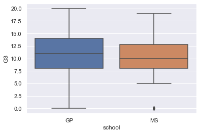

```python
import matplotlib.pyplot as plt
import seaborn as sns
%matplotlib inline
sns.set()
# side by side boxplots of math scores at each school
sns.boxplot(data = students , x = 'school' , y = 'G3');
```

Looking at the plot, we can clearly see that there is a lot of overlap between the boxes (i.e. the middle 50% of the data). Therefore, we can be more confident that there is not much difference between the math scores of the two groups.

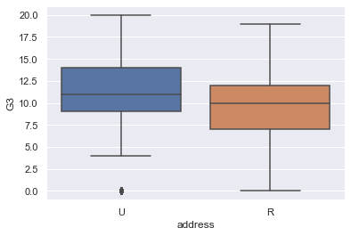

```python
# side by side boxplots of math scores by address
sns.boxplot(data = students , x = 'address' , y = 'G3');
```

Looking at the plot, we can clearly see that there is a lot of overlap between the boxes (i.e. the middle 50% of the data). Therefore, we can be more confident that there is not much difference between the math scores of the two groups.

**Overlapping Histograms**

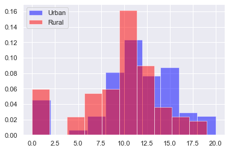

```python
fig, ax = plt.subplots(1, 1) # plot location

ax.hist(scores_urban, alpha=0.5, label='Urban' , density = True , color="blue") # 1st plot
ax.hist(scores_rural, alpha=0.5, label='Rural' , density = True , color = "red") # 2nd plot
ax.legend(loc='upper left')

plt.show();
```

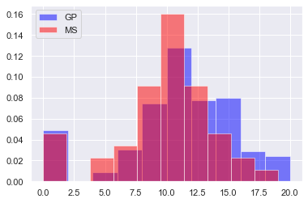

```python
scores_GP = students.G3[students.school == 'GP']
scores_MS = students.G3[students.school == 'MS']
fig, ax = plt.subplots(1, 1)

ax.hist(scores_GP, alpha=0.5, label='GP' , density = True , color="blue")
ax.hist(scores_MS, alpha=0.5, label='MS' , density = True , color = "red")
ax.legend(loc='upper left')

plt.show();
```

While overlapping histograms and side by side boxplots can convey similar information, histograms give us more detail and can be useful in spotting patterns that were not visible in a box plot (eg., a bimodal distribution)

## Quantitative and Non-Binary Categorical Variable

Sometimes we are interested in an association between a quantitative variable and non-binary categorical variable. Non-binary categorical variables have more than two categories.  
When looking at an association between a quantitative variable and a non-binary categorical variable, we must examine all pair-wise differences.  
The easiest way to quickly visualize these comparisons is with side-by-side box plot

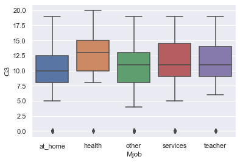

```python
# boxplot of G3 scores compared by Mother's Job
sns.boxplot(data = students, x = 'Mjob', y = 'G3')
plt.show()
```

Visually, we need to compare each box to every other box.  
While most of these boxes overlap with each other, there are some pairs for which there are some apparent differences. For example, scores appear to be higher among students with mothers working in health than among students with mothers working at home or in an “other” job.  
If there are ANY pairwise differences, we can say that the variables are associated; however, it is more useful to specifically report which groups are different

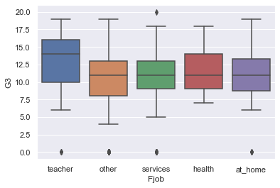

```python
# boxplot of G3 scores compared by Fathers's Job
sns.boxplot(data = students, x = 'Fjob', y = 'G3')
plt.show()
```

While most of these boxes overlap with each other, there are some pairs for which there are some apparent differences. For example, scores appear to be higher among students with fathers working in teaching industry than among students with fathers working at home or in an “other” job.

## Project : Titanic

A new dataset named titanic has been uploaded. This data contains information about passengers on the Titanic, including the amount they paid for their fare and whether or not they survived (note: this is a subset of the full data available). To practice the skills learned in this lesson, let’s investigate whether there is an association between the fare that a passenger paid (Fare) and whether or not they survived (Survived, which is equal to 0 if the passenger died and 1 if they survived):

1. Calculate the difference in mean fare paid by those who survived and those who died. Which group paid a higher average fare?
2. Calculate the difference in median fare for those who survived and those who died.
3. Create side-by-side box plots of fares by survival. Now that you can see the spread of the data, do the mean/median differences seem relatively small or large?
4. Create overlapping histograms of fares by survival (you’ll have to delete or comment out your box plot code before you try to make a histogram). Does this provide any additional information?

```python
# load data
df = pd.read_csv("titanic.csv")
df.head()
```

|  | PassengerId | Survived | Pclass | Name | Sex | Age | SibSp | Parch | Ticket | Fare | Cabin | Embarked |
| --- | --- | --- | --- | --- | --- | --- | --- | --- | --- | --- | --- | --- |
| 0 | 1 | 0 | 3 | Braund, Mr. Owen Harris | male | 22.0 | 1 | 0 | A/5 21171 | 7.2500 | NaN | S |
| 1 | 2 | 1 | 1 | Cumings, Mrs. John Bradley (Florence Briggs Th... | female | 38.0 | 1 | 0 | PC 17599 | 71.2833 | C85 | C |
| 2 | 3 | 1 | 3 | Heikkinen, Miss. Laina | female | 26.0 | 0 | 0 | STON/O2. 3101282 | 7.9250 | NaN | S |
| 3 | 4 | 1 | 1 | Futrelle, Mrs. Jacques Heath (Lily May Peel) | female | 35.0 | 1 | 0 | 113803 | 53.1000 | C123 | S |
| 4 | 5 | 0 | 3 | Allen, Mr. William Henry | male | 35.0 | 0 | 0 | 373450 | 8.0500 | NaN | S |

**Task 1 : Mean & Median Diffrence in fairs**

```python
#separate out fares by survival
fares_died = df.Fare[df.Survived == 0]
fares_survived = df.Fare[df.Survived == 1]
```

```python
#mean difference
mean_fare_died = np.mean(fares_died)
mean_fare_surv = np.mean(fares_survived)
mean_diff = mean_fare_surv-mean_fare_died
print('mean difference: ' + str(mean_diff))
```

```
mean difference: 18.082197554799468
```

```python
#median difference
med_fare_died = np.median(fares_died)
med_fare_surv = np.median(fares_survived)
med_diff = med_fare_surv-med_fare_died
print('median difference: ' + str(median_diff))
```

[output not shown]

**Task 2 :**

1. Side-By-Side Box Plots : Fair by Survived
2. Overlapping Histograms

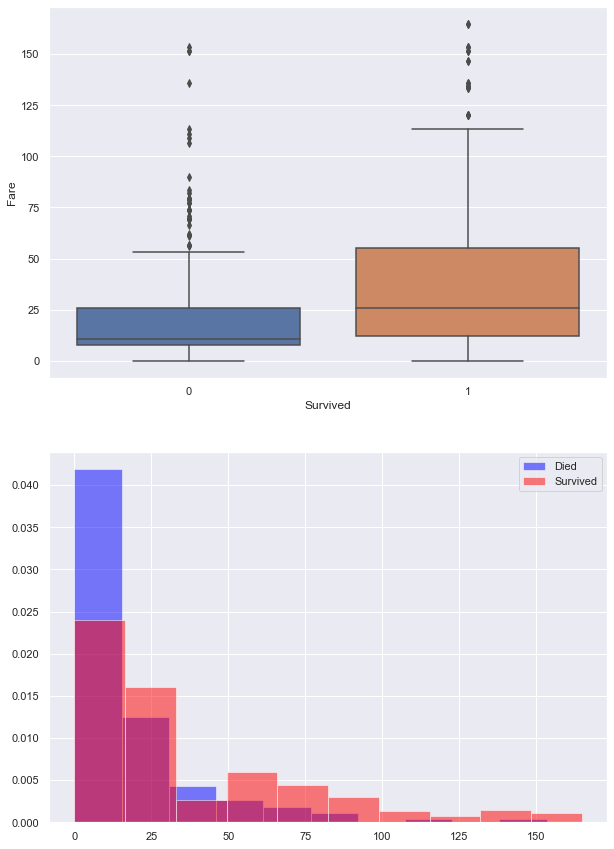

```python
#create subplots (scroll to see plots)
fig = plt.figure(figsize = (10,15))

#create the boxplot:
ax = fig.add_subplot(2,1,1)
ax = sns.boxplot(data = df, x = 'Survived', y = 'Fare')

#create the histograms:
ax = fig.add_subplot(2,1,2)
ax.hist(fares_died, alpha=0.5, label='Died' , density = True , color="blue")
ax.hist(fares_survived, alpha=0.5, label='Survived' , density = True , color = "red")
ax.legend(loc='upper right')

plt.show();
```

1. Median fares are higher for "Survived" and spread out v/s "Died"
2. Higher the Fair more is the chance of Survival

# Association b/w Quantitative and Quantitative Variable

We will examine some data about Texas housing rentals on Craigslist — an online classifieds site. The data dictionary is as follows: price: monthly rental price in U.S.D.  
type: type of housing (eg., 'apartment', 'house', 'condo', etc.)  
sqfeet: housing area, in square feet  
beds: number of beds  
baths: number of baths  
lat: latitude  
long: longitude  
Except for type, all of these variables are quantitative

## Scatter Plots

One of the best ways to quickly visualize the relationship between quantitative variables is to plot them against each other in a **scatter plot**. This makes it easy to look for patterns or trends in the data

```python
# load data
housing = pd.read_csv('housing_sample.csv')
housing .head()
```

|  | price | type | sqfeet | beds | baths | lat | long |
| --- | --- | --- | --- | --- | --- | --- | --- |
| 0 | 615 | apartment | 364 | 0 | 1.0 | 35.1653 | -101.8840 |
| 1 | 1346 | apartment | 816 | 1 | 1.0 | 32.9865 | -96.6860 |
| 2 | 900 | apartment | 500 | 1 | 1.0 | 30.2355 | -97.7292 |
| 3 | 650 | apartment | 700 | 1 | 1.0 | 26.1923 | -98.2657 |
| 4 | 1330 | apartment | 1040 | 2 | 2.0 | 30.6380 | -96.2940 |

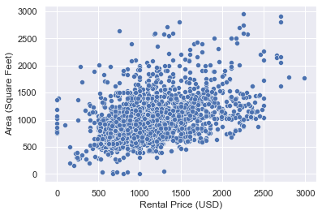

```python
# scatter plot rent v/s area
sns.scatterplot(x = housing.price, y = housing.sqfeet)
plt.xlabel('Rental Price (USD)')
plt.ylabel('Area (Square Feet)')
plt.show();
```

We observe a lot of variation in the data, and also observe that expensive housing tends to come with slightly more space. This suggests an association between these two variables.

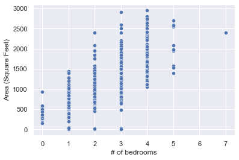

```python
# scatter plot area v/s # of bedrooms
sns.scatterplot(x = housing.beds, y = housing.sqfeet)
plt.xlabel('# of bedrooms')
plt.ylabel('Area (Square Feet)')
plt.show();
```

We observe variation in area as the number of bed rooms increase and also there is a variation in area for housing with the same number of bedrooms

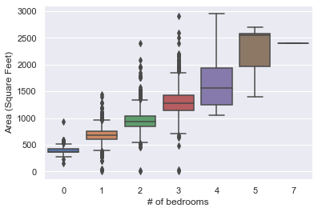

```python
# box plot area v/s # of bedrooms
sns.boxplot(x = housing.beds, y = housing.sqfeet)
plt.xlabel('# of bedrooms')
plt.ylabel('Area (Square Feet)')
plt.show();
```

## Covariance

Covariance is a summary statistic that describes the strength of a linear relationship.A linear relationship is one where a straight line would best describe the pattern of points in a scatter plot.  
Covariance describes how much two random variables vary together. It’s similar to variance, but where variance tells you how a single variable varies, co variance tells you how two variables vary together.  
Covariance can range from $-\infty { to } \infty$. A positive covariance indicates that a larger value of one variable is associated with a larger value of the other. A negative covariance indicates a larger value of one variable is associated with a smaller value of the other. A covariance of 0 indicates no linear relationship.

Cov(X,Y) = Σ E((X-μ)E(Y-ν)) / n-1 where:  
X is a random variable  
E(X) = μ is the expected value (the mean) of the random variable X and  
E(Y) = ν is the expected value (the mean) of the random variable Y  
n = the number of items in the data set

To calculate covariance, we can use the **cov()** function from NumPy, which produces a covariance matrix for two or more variables

```python
# covariance matrix of price v/s size
cov_mat_price_sqfeet = np.cov(housing.price, housing.sqfeet)
print(cov_mat_price_sqfeet)
```

```
[[150471.6135777   65426.51623487]
 [ 65426.51623487 110668.97801735]]
```

*Left Diagonal is the "Covariance" co-efficient that quantifies the strength of covariance.In this case it is 65426*

```python
# covariance matrix of beds vs size
cov_mat_sqfeet_beds = np.cov(housing.sqfeet , housing.beds)
print(cov_mat_sqfeet_beds)
```

```
[[1.10668978e+05 2.28223306e+02]
 [2.28223306e+02 7.24471949e-01]]
```

*Covariance between beds and size is 228.2*

A large covariance can mean a strong relationship between variables. However, you can’t compare variances over data sets with different scales (like pounds and inches). A weak covariance in one data set may be a strong one in a different data set with different scales.

The main problem with interpretation is that the wide range of results that it takes on makes it hard to interpret. For example, your data set could return a value of 3, or 3,000. This wide range of values is cause by a simple fact; The larger the X and Y values, the larger the covariance

## Correlation

Pearson Correlation (often referred to simply as “correlation”) is a scaled form of covariance. It also measures the strength of a linear relationship, but ranges from -1 to +1, making it more interpretable.

Highly associated variables with a positive linear relationship will have a correlation close to 1. Highly associated variables with a negative linear relationship will have a correlation close to -1. Variables that do not have a linear association (or a linear association with a slope of zero) will have correlations close to 0

The pearsonr() function from scipy.stats can be used to calculate the correlation coefficient(r).

Correlation is only useful in determining linear relationship between two variables. Zero correlation may imply no linear dependence, but that does not preclude any other form of dependence (such as, polynomial) between the variables concerned.

Further, correlation does not indicate any cause and effect relationship. Correlation simply quantifies how well two variables are related, if at all, and its direction (i.e. positive or negative).

Typically, the rule of thumb for correlation values is as follows:

1. r between −0.4 and +0.4 indicates absence of linear dependence
2. r between −0.7 and −0.4 or r between +0.4 and +0.7 indicates moderate linear dependence, the sign indicating its direction
3. r less than −0.7 or r greater than +0.7 indicates strong linear dependence

```python
# correlation coefficient between price and area
from scipy.stats import pearsonr
corr_price_sqfeet, p = pearsonr(housing.price, housing.sqfeet)
print(corr_price_sqfeet)
```

```
0.5070065351127468
```

```
0.8060022524416222
```

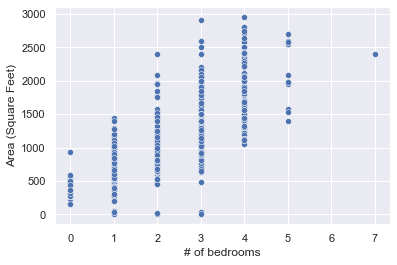

```python
# calculate corr_sqfeet_beds and print it out:
corr_sqfeet_beds, p = pearsonr(housing.beds, housing.sqfeet)
print(corr_sqfeet_beds)

# create the scatter plot here:
sns.scatterplot(x = housing.beds, y = housing.sqfeet)
plt.xlabel('# of bedrooms')
plt.ylabel('Area (Square Feet)')
plt.show();
```

*Area in squarefeet and # of beds are highly corelated*

It’s important to note that there are some limitations to using correlation or covariance as a way of assessing whether there is an association between two variables. Because correlation and covariance both measure the **strength of linear relationships** with non-zero slopes, for any non-linear relationship correlation can be misleading.

The four scatter plots below show pairs of variables with near-zero correlations. The bottom left image shows an example of a perfect linear association where the slope is zero (the line is horizontal). Meanwhile, the other three plots show non-linear relationships — if we drew a line through any of these sets of points, that line would need to be curved, not straight!

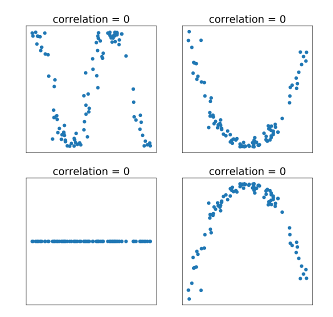

## Project : Penguins

A new dataset named penguins has been uploaded.This dataset contains various measurements for a sample of penguins. To practice the skills learned in this lesson, here are some things to try:

1. Inspect the first few rows of data.
2. Create a scatter plot of flipper length (flipper_length_mm) and body mass (body_mass_g).
3. Inspect your plot. What is the relationship between these variables.
4. Calculate the covariance for these two variables?
5. Calculate the correlation for these two variables. Does this number make sense given the plot you created?

```python
# import packages and libraries
import numpy as np
import pandas as pd
import matplotlib.pyplot as plt
import seaborn as sns
from scipy.stats import pearsonr
np.set_printoptions(suppress=True, precision = 1)
%matplotlib inline
sns.set()
```

```python
# Task -1 import data
df = pd.read_csv("penguins.csv")
df.head()
```

|  | species | bill_length_mm | bill_depth_mm | flipper_length_mm | body_mass_g | sex |
| --- | --- | --- | --- | --- | --- | --- |
| 0 | Adelie | 39.1 | 18.7 | 181 | 3750 | male |
| 1 | Adelie | 39.5 | 17.4 | 186 | 3800 | female |
| 2 | Adelie | 40.3 | 18.0 | 195 | 3250 | female |
| 3 | Adelie | 36.7 | 19.3 | 193 | 3450 | female |
| 4 | Adelie | 39.3 | 20.6 | 190 | 3650 | male |

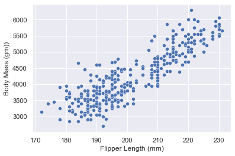

```python
# Task - 2 scatter plot of flipper length (flipper_length_mm) and body mass (body_mass_g)
sns.scatterplot(x = df.flipper_length_mm , y = df.body_mass_g)
plt.xlabel('Flipper Length (mm)')
plt.ylabel('Body Mass (gm))')
plt.show();
```

*Flipper Length and Body Mass exhibit a "+ve" linear relationship*

```python
# Task - 3 covariance flipper length (flipper_length_mm) and body mass (body_mass_g)
cov_mat_flipl_mass = np.cov(df.flipper_length_mm, df.body_mass_g)
print(cov_mat_flipl_mass)
print("covariance: ", cov_mat_flipl_mass[1][0])
```

```
[[   196.4   9852.2]
 [  9852.2 648372.5]]
covariance:  9852.191649480805
```

*Covariance coefficient is 9852 , makes no sense since the units of measure are mm and gm*

```python
# Task - 4 correlation flipper length (flipper_length_mm) and body mass (body_mass_g)
corr_flipl_mass, p = pearsonr(df.flipper_length_mm, df.body_mass_g)
print(corr_flipl_mass)
print("correlation: ", corr_flipl_mass)
```

```
0.8729788985653613
correlation:  0.8729788985653613
```

*Strong Positive Correlation exists between flipper length and body mass*

# Association b/w Categorical and Categorical

We will explore a sample of data from the Narcissistic Personality Inventory (NPI-40), a personality test with 40 questions about personal preferences and self-view. There are two possible responses to each question. The sample contains responses to the following:

- influence: yes = I have a natural talent for influencing people; no = I am not good at influencing people.
- blend_in: yes = I prefer to blend in with the crowd; no = I like to be the center of attention.
- special: yes = I think I am a special person; no = I am no better or worse than most people.
- leader: yes = I see myself as a good leader; no = I am not sure if I would make a good leader.
- authority: yes = I like to have authority over other people; no = I don’t mind following orders.

Responses to some of these questions are associated. For example, if we know whether someone views themself as a good leader, we may also find that they’re more likely to like having authority

## Contingency Tables: Frequencies

Contingency tables, also known as two-way tables or cross-tabulations, are useful for summarizing two variables at the same time.  
We use the **crosstab** function from pandas to create a contingency table

```python
# load data
npi = pd.read_csv("narciscist.csv")
npi.head()
```

|  | influence | blend_in | special | leader | authority |
| --- | --- | --- | --- | --- | --- |
| 0 | no | yes | yes | yes | yes |
| 1 | no | yes | no | no | no |
| 2 | yes | no | yes | yes | yes |
| 3 | yes | no | no | yes | yes |
| 4 | yes | yes | no | yes | no |

Question : Do you think whether there is an association between influence (whether a person thinks they have a talent for influencing people) and leader (whether they see themself as a leader)

```python
# create the contingency table
inluence_leader_freq = pd.crosstab(npi.influence, npi.leader)
inluence_leader_freq
```

| leader influence | no | yes |
| --- | --- | --- |
| no | 3015 | 1293 |
| yes | 2360 | 4429 |

This table tells us the number of people who gave each possible combination of responses to these two questions. For example, 2360 people said that they do not see themselves as a leader but have a talent for influencing people.

To assess whether there is an association between these two variables, we need to ask **whether information about one variable gives us information about the other**. In this example, we see that among people who don’t see themselves as a leader (the first column), a larger number (3015) don’t think they have a talent for influencing people. Meanwhile, among people who do see themselves as a leader (the second column), a larger number (4429) do think they have a talent for influencing people.

So, if we know how someone responded to the leadership question, we have some information about how they are likely to respond to the influence question. This suggests that the variables are associated

Question : Do you think there will be an association between special (whether or not a person sees themself as “special”) and authority (whether or not a person likes to have authority)?

```python
# create the contingency table
special_authority_freq = pd.crosstab(npi.special, npi.authority)
special_authority_freq
```

| authority special | no | yes |
| --- | --- | --- |
| no | 4069 | 1905 |
| yes | 2229 | 2894 |

*2894 people with autority think they are special whilst 4069 people without autority do not think they are special. This implies that having authority and being treated as special are associated*

## Contingency Tables: Proportions

Sometimes it’s helpful to convert frequencies from a contingency table into proportions. We can accomplish this by dividing the all the frequencies in a contingency table by the total number of observations (the sum of the frequencies).The resulting contingency table makes it slightly easier to compare the proportion of people in each category

```python
influence_leader_freq = pd.crosstab(npi.influence, npi.leader)
influence_leader_prop = influence_leader_freq/len(npi)
inluence_leader_freq
```

| leader influence | no | yes |
| --- | --- | --- |
| no | 3015 | 1293 |
| yes | 2360 | 4429 |

```python
influence_leader_prop
```

| leader influence | no | yes |
| --- | --- | --- |
| no | 0.271695 | 0.116518 |
| yes | 0.212670 | 0.399117 |

We see that the two largest proportions in the table (.399 and .271) are in the yes/yes and no/no cells of the table. We can also see that almost 40% of the surveyed population (by far the largest proportion) both see themselves as leaders and think they have a talent for influencing people.

```python
# create the contingency table
special_authority_freq = pd.crosstab(npi.special, npi.authority)
special_authority_prop = special_authority_freq/len(npi)
special_authority_freq
```

| authority special | no | yes |
| --- | --- | --- |
| no | 4069 | 1905 |
| yes | 2229 | 2894 |

```python
special_authority_prop
```

| authority special | no | yes |
| --- | --- | --- |
| no | 0.366676 | 0.171668 |
| yes | 0.200865 | 0.260791 |

We see that the two largest proportions in the table (.26 and .36) are in the yes/yes and no/no cells of the table. We can also see that almost 37% of the surveyed population (by far the largest proportion) don't see themselves as having authority over people and don't feel they are treated as special persons

## Contingency Tables : Marginal Proportions

In the previous exercises, we looked at an association between the influence and leader questions using a contingency table. We saw some evidence of an association between these questions.

Now, let’s take a moment to think about what the tables would look like if there were no association between the variables. Our first instinct may be that there would be .25 (25%) of the data in each of the four cells of the table, but that is not the case. Let’s take another look at our contingency table.

```python
influence_leader_prop
```

| leader influence | no | yes |
| --- | --- | --- |
| no | 0.271695 | 0.116518 |
| yes | 0.212670 | 0.399117 |

Notice that the bottom row, which corresponds to people who think they have a talent for influencing people, accounts for 0.213 + 0.399 = 0.612 (or 61.2%) of surveyed people — more than half! This means that we can expect higher proportions in the bottom row, regardless of whether the questions are associated.  
**The proportion of respondents in each category of a single question is called a marginal proportion.**  
For example, the marginal proportion of the population that has a talent for influencing people is 0.612. We can calculate all the marginal proportions from the contingency table of proportions (saved as influence_leader_prop) using row and column sums.  
**axis=0 -- Row Sum ; axis=1 -- Column Sum**

```python
# calculate Row Sums (axis=0)
leader_marginals = influence_leader_prop.sum(axis=0)
print(leader_marginals)
# calculate Column Sums (axis=1)
influence_marginals =  influence_leader_prop.sum(axis=1)
print(influence_marginals)
```

```
leader
no     0.484365
yes    0.515635
dtype: float64
influence
no     0.388213
yes    0.611787
dtype: float64
```

*Inference : While respondents are approximately split on whether they see themselves as a leader (51%), more people (61%) think they have a talent for influencing people than not*

```python
# save the table of frequencies as special_authority_freq:
special_authority_freq = pd.crosstab(npi.special, npi.authority)
print('Frequency Table : Special  v/s Authority')
print(special_authority_freq)
# save the table of proportions as special_authority_prop:
special_authority_prop = special_authority_freq/len(npi)
print('Proportion Table : Special v/s Authority')
print(special_authority_prop)
# calculate and print authority_marginals
authority_marginals = special_authority_prop.sum(axis=0)
print('Marginal Proportions Authority')
print(authority_marginals)
# calculate and print special_marginals
special_marginals = special_authority_prop.sum(axis=1)
print('Marginal Proportions Special')
print(special_marginals)
```

```
Frequency Table : Special  v/s Authority
authority    no   yes
special
no         4069  1905
yes        2229  2894
Proportion Table : Special v/s Authority
authority        no       yes
special
no         0.366676  0.171668
yes        0.200865  0.260791
Marginal Proportions Authority
authority
no     0.567541
yes    0.432459
dtype: float64
Marginal Proportions Special
special
no     0.538344
yes    0.461656
dtype: float64
```

*Inference : While 56% of people feel they do not like to have authority over others , they also think they are not Special*

## Contingency Tables : Expected Propostions

In order to understand whether questions are associated, we can use the marginal proportions to create a contingency table of **expected proportions if there were no association between these variables**. To calculate these expected proportions, we need to multiply the marginal proportions for each combination of categories

```python
leader_marginals
```

```
leader
no     0.484365
yes    0.515635
dtype: float64
```

```python
influence_marginals
```

```
influence
no     0.388213
yes    0.611787
dtype: float64
```

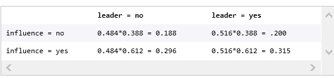

These proportions can then be converted to frequencies by multiplying each one by the sample size (11097 for this data)

```python
len(npi)
```

```
11097
```

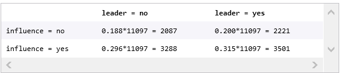

This table now tells us that if there were no association between the leader and influence questions, we would expect 2087 people to answer no to both.  
In python, we can calculate this table using the **chi2_contingency()** function from SciPy, by passing in the observed frequency table.This gives us 4 outputs chi2, pval, dof, expected. We will only look at "expected".

```python
from scipy.stats import chi2_contingency
chi2, pval, dof, expected = chi2_contingency(influence_leader_freq)
print("Expected Frequency")
print(np.round(expected))
```

```
Expected Frequency
[[2087. 2221.]
 [3288. 3501.]]
```

Note that the ScyPy function returned the same expected frequencies as we calculated “by hand” above! Now that we have the expected contingency table if there’s no association, we can compare it to our observed contingency table

```python
print("Expected Frequency")
print(np.round(expected))
print("Observed Frequency")
print(influence_leader_freq)
```

```
Expected Frequency
[[2087. 2221.]
 [3288. 3501.]]
Observed Frequency
leader       no   yes
influence
no         3015  1293
yes        2360  4429
```

**The more that the expected and observed tables differ, the more sure we can be that the variables are associated.** In this example, we see some pretty big differences (eg., 3015 in the observed table compared to 2087 in the expected table). This provides additional evidence that these variables are associated

```python
# Observed Frequency Table : Special v/s Authority
special_authority_freq = pd.crosstab(npi.special, npi.authority)
print("Observed Frequency:")
# Calculate the expected contingency table if there's no association and save it as expected
chi2, pval, dof, expected = chi2_contingency(special_authority_freq)
```

```
Observed Frequency:
```

| authority special | no | yes |
| --- | --- | --- |
| no | 4069 | 1905 |
| yes | 2229 | 2894 |

```python
# print out the expected frequency table
print("Expected Frequency")
print(np.round(expected))
# print out the observed frequency table
print("Observed Frequency")
print(special_authority_freq)
```

```
Expected Frequency
[[3390. 2584.]
 [2908. 2215.]]
Observed Frequency
authority    no   yes
special
no         4069  1905
yes        2229  2894
```

In this example, we see some pretty big differences (eg., 4069 in the observed table compared to 3390 in the expected table & 2894 in the observed table compared 2215 in the expected table). This provides additional evidence that these variables are associated.

## The Chi-Square Statistic

In the previous exercise, we calculated a contingency table of expected frequencies if there were no association between the leader and influence questions. We then compared this to the observed contingency table. Because the tables looked somewhat different, we concluded that responses to these questions are probably associated.

```python
from scipy.stats import chi2_contingency
chi2, pval, dof, expected = chi2_contingency(influence_leader_freq)
print(chi2)
```

```
1307.8836807573769
```

The interpretation of the Chi-Square statistic is dependent on the size of the contingency table.  
**For a 2x2 table (like the one we’ve been investigating), a Chi-Square statistic larger than around 4 would strongly suggest an association between the variables.** In this example, our Chi-Square statistic is much larger than that — 1307.88! This adds to our evidence that the variables are highly associated

```python
# contingency table special v/s authority
special_authority_freq = pd.crosstab(npi.special, npi.authority)

# chisquare statistic and expected frequencies
chi2, pval, dof, expected = chi2_contingency(influence_leader_freq)
```

```python
# print observed frequencies
print("Observed")
print(special_authority_freq)
# print expected frequencies
print("Expected")
print(np.round(expected))
# print chi-square statistic
print("Chi Square")
print(chi2)
```

[output not shown]

**Association between Leader and Authority**

```python
# contingency table leader v/s authority
leader_authority_freq = pd.crosstab(npi.leader, npi.authority)

# chisquare statistic and expected frequencies
chila2, pval, dof, expectedla2 = chi2_contingency(leader_authority_freq)
```

```python
# Observed
leader_authority_freq
```

| authority leader | no | yes |
| --- | --- | --- |
| no | 3820 | 1555 |
| yes | 2478 | 3244 |

```python
# Expected
np.round(expectedla2)
```

```
array([[3051., 2324.],
       [3247., 2475.]])
```

```python
# Chi Square
chila2
```

```
869.2684782761069
```

## Project NBA Trends

In this project, you’ll analyze data from the NBA (National Basketball Association) and explore possible associations.

This data was originally sourced from 538’s Analysis of the Complete History Of The NBA and contains the original, unmodified data from Basketball Reference as well as several additional variables 538 added to perform their own analysis.

For this project we’ve limited the data to just 5 teams and 10 columns (plus one constructed column, point_diff, the difference between pts and opp_pts).

**Analyzing relationships between Quant and Categorical**

```python
# import packages
import pandas as pd
import numpy as np
np.set_printoptions(suppress=True, precision = 2)
import matplotlib.pyplot as plt
import seaborn as sns
%matplotlib inline
sns.set()
from scipy.stats import pearsonr, chi2_contingency
```

```python
# import data
nba = pd.read_csv('nba_trends.csv')
nba.head().T
```

|  | 0 | 1 | 2 | 3 | 4 |
| --- | --- | --- | --- | --- | --- |
| game_id | 194611010TRH | 194611020CHS | 194611020PRO | 194611050BOS | 194611070STB |
| year_id | 1947 | 1947 | 1947 | 1947 | 1947 |
| fran_id | Knicks | Knicks | Celtics | Celtics | Knicks |
| opp_fran | Huskies | Stags | Steamrollers | Stags | Bombers |
| game_location | A | A | A | H | A |
| is_playoffs | 0 | 0 | 0 | 0 | 0 |
| pts | 68 | 47 | 53 | 55 | 68 |
| opp_pts | 66 | 63 | 59 | 57 | 63 |
| game_result | W | L | L | L | W |
| forecast | 0.359935 | 0.368899 | 0.359935 | 0.620204 | 0.33929 |
| point_diff | 2 | -16 | -6 | -2 | 5 |

Create subsets for games from 2010 (named nba_2010) and games from 2014 (named nba_2014)

```python
# Subset Data to 2010 Season, 2014 Season
nba_2010 = nba[nba.year_id == 2010]
nba_2014 = nba[nba.year_id == 2014]
```

```python
nba_2014.info()
```

```
<class 'pandas.core.frame.DataFrame'>
Int64Index: 464 entries, 23468 to 23931
Data columns (total 11 columns):
 #   Column         Non-Null Count  Dtype
---  ------         --------------  -----
 0   game_id        464 non-null    object
 1   year_id        464 non-null    int64
 2   fran_id        464 non-null    object
 3   opp_fran       464 non-null    object
 4   game_location  464 non-null    object
 5   is_playoffs    464 non-null    int64
 6   pts            464 non-null    int64
 7   opp_pts        464 non-null    int64
 8   game_result    464 non-null    object
 9   forecast       464 non-null    float64
 10  point_diff     464 non-null    int64
dtypes: float64(1), int64(5), object(5)
memory usage: 43.5+ KB
```

```python
nba_2010.info()
```

```
<class 'pandas.core.frame.DataFrame'>
Int64Index: 450 entries, 21717 to 22166
Data columns (total 11 columns):
 #   Column         Non-Null Count  Dtype
---  ------         --------------  -----
 0   game_id        450 non-null    object
 1   year_id        450 non-null    int64
 2   fran_id        450 non-null    object
 3   opp_fran       450 non-null    object
 4   game_location  450 non-null    object
 5   is_playoffs    450 non-null    int64
 6   pts            450 non-null    int64
 7   opp_pts        450 non-null    int64
 8   game_result    450 non-null    object
 9   forecast       450 non-null    float64
 10  point_diff     450 non-null    int64
dtypes: float64(1), int64(5), object(5)
memory usage: 42.2+ KB
```

**Task 1 : Suppose you want to compare the knicks to the nets with respect to points earned per game. Using the pts column from the nba_2010 DataFrame, create two series named knicks_pts (fran_id = "Knicks") and nets_pts(fran_id = "Nets") that represent the points each team has scored in their games**

```python
nba_2014.head()
```

|  | game_id | year_id | fran_id | opp_fran | game_location | is_playoffs | pts | opp_pts | game_result | forecast | point_diff |
| --- | --- | --- | --- | --- | --- | --- | --- | --- | --- | --- | --- |
| 23468 | 201310300CLE | 2014 | Nets | Cavaliers | A | 0 | 94 | 98 | L | 0.611981 | -4 |
| 23469 | 201310300NYK | 2014 | Knicks | Bucks | H | 0 | 90 | 83 | W | 0.793150 | 7 |
| 23470 | 201310300SAS | 2014 | Spurs | Grizzlies | H | 0 | 101 | 94 | W | 0.692980 | 7 |
| 23471 | 201310300TOR | 2014 | Celtics | Raptors | A | 0 | 87 | 93 | L | 0.361233 | -6 |
| 23472 | 201310300UTA | 2014 | Thunder | Jazz | A | 0 | 101 | 98 | W | 0.526056 | 3 |

```python
nba_2010.head()
```

|  | game_id | year_id | fran_id | opp_fran | game_location | is_playoffs | pts | opp_pts | game_result | forecast | point_diff |
| --- | --- | --- | --- | --- | --- | --- | --- | --- | --- | --- | --- |
| 21717 | 200910270CLE | 2010 | Celtics | Cavaliers | A | 0 | 95 | 89 | W | 0.277472 | 6 |
| 21718 | 200910280BOS | 2010 | Celtics | Hornets | H | 0 | 92 | 59 | W | 0.814619 | 33 |
| 21719 | 200910280MIA | 2010 | Knicks | Heat | A | 0 | 93 | 115 | L | 0.258755 | -22 |
| 21720 | 200910280MIN | 2010 | Nets | Timberwolves | A | 0 | 93 | 95 | L | 0.475155 | -2 |
| 21721 | 200910280OKC | 2010 | Thunder | Kings | H | 0 | 102 | 89 | W | 0.716764 | 13 |

```python
knicks_pts = nba_2010.pts[nba.fran_id=='Knicks']
nets_pts = nba_2010.pts[nba.fran_id=='Nets']
```

**Task 2 : Calculate the difference between the two teams’ average points scored and save the result as diff_means_2010. Based on this value, do you think fran_id and pts are associated? Why or why not?**

```python
knicks_mean = np.mean(knicks_pts)
nets_mean = np.mean(nets_pts)
diff_means_2010 = knicks_mean - nets_mean

print("Average Points Scored by Knicks in 2010 : " + str(knicks_mean))
print("Average Points Scored by Nets in 2010 : " + str(nets_mean))
print("Difference in Average Points Scored in 2010 :" + str(diff_means_2010))
```

```
Average Points Scored by Knicks in 2010 : 102.10975609756098
Average Points Scored by Nets in 2010 : 92.3780487804878
Difference in Average Points Scored in 2010 :9.731707317073173
```

*Inference : There is only a 10 point difference in means , which is marginal and cannot be used as a statistic to compare performance of Knicks and Nets in 2010*

**Task 3: Create a set of overlapping histograms that can be used to compare the points scored for the Knicks compared to the Nets**

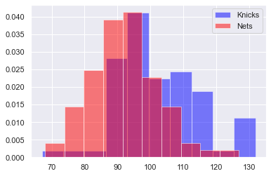

```python
fig, ax = plt.subplots(1, 1)
ax.hist(knicks_pts, alpha=0.5, label='Knicks' , density = True , color="blue")
ax.hist(nets_pts, alpha=0.5, label='Nets' , density = True , color = "red")
ax.legend(loc='upper right')
plt.show();
```

*Inference : Distributions fairly overlap excepting where scores are > 110 points*

**Task 4 : Compare points scored in 2014**

```python
# create subsets with year = 2014
knicks_pts_2014 = nba_2014.pts[nba.fran_id=='Knicks']
nets_pts_2014 = nba_2014.pts[nba.fran_id=='Nets']
```

```python
# view top 5 rows
print(knicks_pts_2014.head())
print(nets_pts_2014.head())
```

```
23469     90
23473     81
23480    100
23486     97
23490    101
Name: pts, dtype: int64
23468     94
23475    101
23482     86
23484    104
23494    108
Name: pts, dtype: int64
```

```python
# calculate average scores and difference in average scores for 2014
knicks_mean_2014 = np.mean(knicks_pts_2014)
nets_mean_2014 = np.mean(nets_pts_2014)
diff_means_2014 = knicks_mean_2014 - nets_mean_2014

print("Average Points Scored by Knicks in 2014 : " + str(knicks_mean_2014))
print("Average Points Scored by Nets in 2014 : " + str(nets_mean_2014))
print("Difference in Average Points Scored in 2014 :" + str(diff_means_2014))
```

```
Average Points Scored by Knicks in 2014 : 98.58536585365853
Average Points Scored by Nets in 2014 : 98.13829787234043
Difference in Average Points Scored in 2014 :0.44706798131809933
```

*Inference : There is only 0.5 point difference in means implying performance of Knicks and Nets in 2014 are similar*

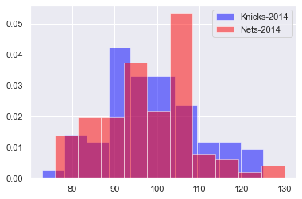

```python
# plot the overlapping histograms knicks and nest 2014
fig, ax = plt.subplots(1, 1)
ax.hist(knicks_pts_2014, alpha=0.5, label='Knicks-2014' , density = True , color="blue")
ax.hist(nets_pts_2014, alpha=0.5, label='Nets-2014' , density = True , color = "red")
ax.legend(loc='upper right')
plt.show();
```

**Task 4: Using nba_2010, generate side-by-side boxplots with points scored (pts) on the y-axis and team (fran_id) on the x-axis. Is there any overlap between the boxes? Does this chart suggest that fran_id and pts are associated? Which pairs of teams, if any, earn different average scores per game?**

```python
# 1st 5 rows
nba_2010.head()
```

|  | game_id | year_id | fran_id | opp_fran | game_location | is_playoffs | pts | opp_pts | game_result | forecast | point_diff |
| --- | --- | --- | --- | --- | --- | --- | --- | --- | --- | --- | --- |
| 21717 | 200910270CLE | 2010 | Celtics | Cavaliers | A | 0 | 95 | 89 | W | 0.277472 | 6 |
| 21718 | 200910280BOS | 2010 | Celtics | Hornets | H | 0 | 92 | 59 | W | 0.814619 | 33 |
| 21719 | 200910280MIA | 2010 | Knicks | Heat | A | 0 | 93 | 115 | L | 0.258755 | -22 |
| 21720 | 200910280MIN | 2010 | Nets | Timberwolves | A | 0 | 93 | 95 | L | 0.475155 | -2 |
| 21721 | 200910280OKC | 2010 | Thunder | Kings | H | 0 | 102 | 89 | W | 0.716764 | 13 |

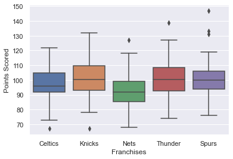

```python
# box plot points v/s franchises
sns.boxplot(x = nba_2010.fran_id, y = nba_2010.pts)
plt.xlabel('Franchises')
plt.ylabel('Points Scored')
plt.show();
```

**Analyzing relationships between Categorical variables**  
The variable game_result indicates whether a team won a particular game ('W' stands for “win” and 'L' stands for “loss”). The variable game_location indicates whether a team was playing at home or away ('H' stands for “home” and 'A' stands for “away”). Do teams tend to win more games at home compared to away?

1. Data scientists will often calculate a contingency table of frequencies to help them determine if categorical variables are associated. Calculate a table of frequencies that shows the counts of game_result and game_location.Save your result as location_result_freq and print your result. Based on this table, do you think the variables are associated?

*Frequency Table : game_result v/s game_location*

```python
location_result_freq = pd.crosstab(nba_2010.game_location ,nba_2010.game_result)
location_result_freq
```

| game_result game_location | L | W |
| --- | --- | --- |
| A | 133 | 92 |
| H | 105 | 120 |

*Inference : Maxium Wins are when playing at Home and Maximum Losses are when playing Away*

1. Convert this table of frequencies to a table of proportions and save the result as location_result_proportions. Print your result

*Table of Observed Proportions*

```python
location_result_proportions = location_result_freq/len(nba_2010)
location_result_proportions
```

| game_result game_location | L | W |
| --- | --- | --- |
| A | 0.295556 | 0.204444 |
| H | 0.233333 | 0.266667 |

*Inference : We observe largest proportion of Wins is "Home" and Largest proportion of Losses is "Away"*

1. Using the contingency table created in the previous exercise , calculate the expected contingency table (if there were no association) and the Chi-Square statistic and print your results. Does the actual contingency table look similar to the expected table — or different? Based on this output, do you think there is an association between these variables?

```python
# apply chi2 test
chi2, pval, dof, expected = chi2_contingency(location_result_freq)
print("Observed Frequencies")
print(location_result_freq)
print("Expected Frequencies")
print(expected)
print("Chi Squared Statistic")
print(chi2)
```

```
Observed Frequencies
game_result      L    W
game_location
A              133   92
H              105  120
Expected Frequencies
[[119. 106.]
 [119. 106.]]
Chi Squared Statistic
6.501704455367053
```

*Inference : Observed frequencies are comparable to frequencies both for Wins and Losses with Chi Squared value of 6.5 which is marginally > 4 indicating a moderate association between Location of Game Playes and Wins*

**Analyzing Relationships Between Quantitative Variables**  
For each game, 538 has calculated the probability that each team will win the game. In the data, this is saved as forecast. The point_diff column gives the margin of victory/defeat for each team (positive values mean that the team won; negative values mean that they lost). Did teams with a higher probability of winning (according to 538) also tend to win games by more points?

1. Using nba_2010, calculate the covariance between forecast (538’s projected win probability) and point_diff (the margin of victory/defeat) in the dataset.Save and print your result.Looking at the matrix, what is the covariance between these two variables?

```python
nba_2010.head()
```

|  | game_id | year_id | fran_id | opp_fran | game_location | is_playoffs | pts | opp_pts | game_result | forecast | point_diff |
| --- | --- | --- | --- | --- | --- | --- | --- | --- | --- | --- | --- |
| 21717 | 200910270CLE | 2010 | Celtics | Cavaliers | A | 0 | 95 | 89 | W | 0.277472 | 6 |
| 21718 | 200910280BOS | 2010 | Celtics | Hornets | H | 0 | 92 | 59 | W | 0.814619 | 33 |
| 21719 | 200910280MIA | 2010 | Knicks | Heat | A | 0 | 93 | 115 | L | 0.258755 | -22 |
| 21720 | 200910280MIN | 2010 | Nets | Timberwolves | A | 0 | 93 | 95 | L | 0.475155 | -2 |
| 21721 | 200910280OKC | 2010 | Thunder | Kings | H | 0 | 102 | 89 | W | 0.716764 | 13 |

```python
# covariance matrix of forecast v/s point diff
cov_mat_forecast_pointsdiff = np.cov(nba_2010.forecast, nba_2010.point_diff)
print(cov_mat_forecast_pointsdiff)
```

```
[[  0.05   1.37]
 [  1.37 186.56]]
```

*Inference : There exists a 1.37 Covariance between Forecast and Point Difference*

1. Using nba_2010, calculate the correlation between forecast and point_diff. Does this value suggest an association between the two variables?

```python
# correaltion coefficient between forecast and point diff
from scipy.stats import pearsonr
corr_forecast_pointsdiff, p = pearsonr(nba_2010.forecast, nba_2010.point_diff)
print(corr_forecast_pointsdiff)
```

```
0.44020887084680815
```

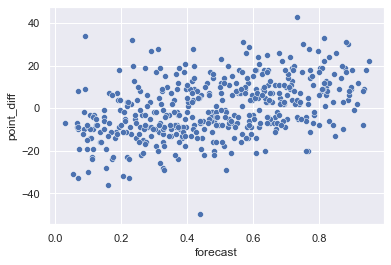

```python
# scatter plot of forecast v/s point diff
sns.scatterplot(x = nba_2010.forecast , y = nba_2010.point_diff)
plt.show();
```